# ФББ - R - Домашнее задание №4

Данил Сидиков

01 10 2023

# Подгрузка пакетов

```r
library('tidyverse') #загрузим установленный пакет tidyverse в текущую R сессию
```

# Задание №1

> Возьмите встроенный датасет **msleep** - в нем содержится информация о времени сна и бодрствования различных животных. Больше информации об этом датасете можно узнать в справке **?msleep**.

> С помощью диаграммы рассеяния изобразите зависимость общей длительности сна **(sleep_total)** от логарифма веса животного **(bodywt)**. Пояснения:
- Цветом обозначьте, чем животное питается (vore).
- Измените порядок названий категорий в легенде (на любой отличный от дефолтного).
- Переместите легенду наверх графика.
- Подпишите оси, добавьте название графика.
- Подберите цветовую палитру.

> Сохраните график в подходящем размере и удобном вам формате.

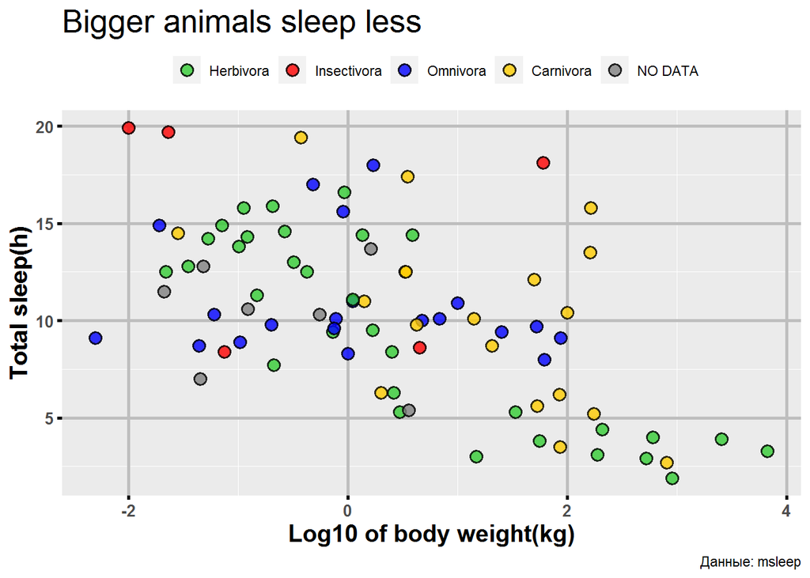

```r
p <- ggplot(data=msleep,
       mapping=aes(x = log10(bodywt),
                   y = sleep_total)) +
  #Зададим порядок значений и стиль точек
    geom_point(aes(fill = factor(vore, levels = c("herbi", "insecti", "omni","carni", NA))),
               shape=21,
               size=3,
               alpha=0.8,
               stroke=1) +
  #Введем легенду по цветам и значениям
    scale_fill_manual(values = c("#33CC33", "#FF0000","#0000FF","#FFCC00","black"),
                      labels = c("Herbivora","Insectivora","Omnivora","Carnivora","NO DATA")) +
  #Введем обозначения
    labs(title="Bigger animals sleep less",
         caption = "Данные: msleep",
         x = "Log10 of body weight(kg)",
         y = "Total sleep(h)") +
  #Зададим собственную тему
    theme(plot.title = element_text(size = 20),
          axis.text = element_text(size = 10,
                                   face = "bold"),
          axis.title = element_text(size = 15,
                                    face = "bold"),
          panel.grid.major = element_line(color = "grey",
                                          linewidth = 1),
          axis.ticks = element_line(color = "black",
                                    linewidth = 1),
          legend.position = "top",
          legend.title=element_blank())
p
```

```r
#Сохраним график
ggsave(
  "figures/sleepandmass.png", p,
  dpi = 300, width = 20, height = 10, units = "cm")
```

# Задание №2

> Возьмите встроенный датасет starwars - в нем содержится информация о персонажах вселенной Звездные Войны. Больше информации об этом датасете можно узнать в справке **?starwars**.

> Отберите 2 планеты **(homeworld)**, которые являются родиной самого большого количества героев ЗВ. Отберите только тех персонажей, которые происходят с этих двух планет, и постройте **график дотплот** (с помощью функции geom_point()), который бы показывал **вес (mass)** персонажей разных **рас (species)**. **По оси X - вес тела, по Y - раса (species)**, каждая точка - один персонаж. Цветом точки покажите **гендерную идентичность героя (gender)** информацию о расе, размером точки - его **рост (height)**.

> Подпишите оси, добавьте название графика и подберите цветовую палитру.

> Сохраните график в подходящем размере и удобном вам формате.

```r
most <- as.data.frame(table(starwars$homeworld)) #Сформируем DataFrame планет по популярности
head(arrange(most, desc(Freq)), n=3) #Выведем топ 3
```

```
##       Var1 Freq
## 1    Naboo   11
## 2 Tatooine   10
## 3 Alderaan    3
```

```r
Planet1 <- as.character(arrange(most, desc(Freq))[1,'Var1']) #Занесем в переменные две самые популярные планеты
Planet2 <- as.character(arrange(most, desc(Freq))[2,'Var1'])
Planet1
```

```
## [1] "Naboo"
```

```r
Planet2
```

```
## [1] "Tatooine"
```

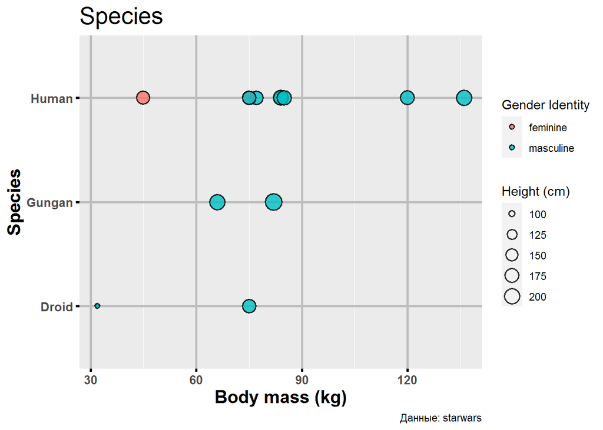

```r
Hero <- starwars %>%
    filter((homeworld == Planet1 | homeworld == Planet2)& !is.na(species)) #Отберем героев с этих двух планет

g <- ggplot(data=Hero,
       mapping=aes(x = mass,
                   y = species)) +
  #Зададим стиль точек
    geom_point(aes(fill = gender, size = height), #размер-рост, наполнение-цвет
               shape=21,
               alpha=0.8,
               stroke=1) +
  #Зададим обозначения
    labs(title="Species",
         caption = "Данные: starwars",
         x = "Body mass (kg)",
         y = "Species") +
    labs(fill = "Gender Identity", size="Height (cm)")+
  #Зададим собственную тему
    theme(plot.title = element_text(size = 20),
          axis.text = element_text(size = 10,
                                   face = "bold"),
          axis.title = element_text(size = 15,
                                    face = "bold"),
          panel.grid.major = element_line(color = "grey",
                                          linewidth = 1),
          axis.ticks = element_line(color = "black",
                                    linewidth = 1),
          legend.position = "right")
g
```

```r
#Cохраним график
ggsave(
  "figures/homeworld.png", g,
  dpi = 300, width = 20, height = 10, units = "cm")
```

# Задание №3

> Прочитайте датасет о напитках из Старбакса по ссылке https://raw.githubusercontent.com/rfordatascience/tidytuesday/master/data/2021/2021-12-21/starbucks.csv.

> В этом датасете содержатся столбцы:
- product_name - наименование напитка,
- size - размер (категория),
- milk - тип молока:
  - 0 - без молока,
  - 1 - обезжиренное молоко,
  - 2 - 2% молоко,
  - 3 - соевое молоко,
  - 4 - кокосовое молоко,
  - 5 - цельное молоко,
- whip - добавляют ли сливки (0/1),
- serv_size_m_l - объем напитка (мл),
- calories - калории (ккал),
- total_fat_g - содержание жира (г),
- saturated_fat_g - содержание насыщенных жиров (г),
- trans_fat_g - содержание транс-жиров (г),
- cholesterol_mg - содержание холестерина (мг),
- sodium_mg - содержание натрия (мг),
- total_carbs_g - содержание углеводов (г),
- fiber_g- содержание пищевых волокон (г),
- sugar_g - содержание сахара (г),
- caffeine_mg - содержание кофеина (мг).

> Отберите только напитки, подходящие под следующие условия:
- напитки, приготовляемые без молока, 2% молоке или соевом молоке,
- напитки объемом 473 мл,
- не бескалорийные напитки,
- напитки, содержащие кофеин.

> С помощью диаграммы рассеяния изобразите зависимость содержание кофеина **(caffeine_mg)** от калорийности напитка **(calories)**. Цветом обозначьте тип молока.

> На графике обозначьте **пунктирной линией (используйте geom_hline(…, linetype = “dashed”), например)** самое частое (мода) для отобранных напитков значение содержания кофеина. Поменяйте порядок задаваемых геометрических объектов **(geom_*)**, чтобы линия проходила под точками.

> Поменяйте отображаемые по осям значения так, чтобы интервал между ними составлял 50. Это можно сделать с помощью **scale_x_continuous(breaks = *вектор с отображаемыми значениями*)** и **scale_y_continuous(breaks = *вектор с отображаемыми значениями*)**.

> Пусть в легенде будут перечислены категории напитков следующим образом:
- напитки без молока - no milk
- напитки на 2% молоке - 2% milk
- напитки на соевом молоке - soy milk

> Подпишите оси, добавьте название графика и подберите цветовую палитру.

> Сохраните график в подходящем размере и удобном вам формате.

```r
#Прочитаем данные
drinks <- read_csv("https://raw.githubusercontent.com/rfordatascience/tidytuesday/master/data/2021/2021-12-21/starbucks.csv") #Прочитаем датасет
#Покажем данные
head(drinks)
```

```
## # A tibble: 6 x 15
##   product_name              size   milk  whip serv_size_m_l calories total_fat_g
##   <chr>                     <chr> <dbl> <dbl>         <dbl>    <dbl>       <dbl>
## 1 brewed coffee - dark roa~ short     0     0           236        3         0.1
## 2 brewed coffee - dark roa~ tall      0     0           354        4         0.1
## 3 brewed coffee - dark roa~ gran~     0     0           473        5         0.1
## 4 brewed coffee - dark roa~ venti     0     0           591        5         0.1
## 5 brewed coffee - decaf pi~ short     0     0           236        3         0.1
## 6 brewed coffee - decaf pi~ tall      0     0           354        4         0.1
## # i 8 more variables: saturated_fat_g <dbl>, trans_fat_g <chr>,
## #   cholesterol_mg <dbl>, sodium_mg <dbl>, total_carbs_g <dbl>, fiber_g <chr>,
## #   sugar_g <dbl>, caffeine_mg <dbl>
```

```r
fil_drinks <- drinks %>% #отберем напитки по условию
  filter((milk == 0 | milk == 2 | milk == 3) & (serv_size_m_l == 473) & (calories>0) & (caffeine_mg>0))
#Покажем их
head(fil_drinks)
```

```
## # A tibble: 6 x 15
##   product_name              size   milk  whip serv_size_m_l calories total_fat_g
##   <chr>                     <chr> <dbl> <dbl>         <dbl>    <dbl>       <dbl>
## 1 brewed coffee - dark roa~ gran~     0     0           473        5         0.1
## 2 brewed coffee - decaf pi~ gran~     0     0           473        5         0.1
## 3 brewed coffee - medium r~ gran~     0     0           473        5         0.1
## 4 brewed coffee - True Nor~ gran~     0     0           473        5         0.1
## 5 Caffe Misto               gran~     2     0           473      110         4
## 6 Caffe Misto               gran~     3     0           473       80         3
## # i 8 more variables: saturated_fat_g <dbl>, trans_fat_g <chr>,
## #   cholesterol_mg <dbl>, sodium_mg <dbl>, total_carbs_g <dbl>, fiber_g <chr>,
## #   sugar_g <dbl>, caffeine_mg <dbl>
```

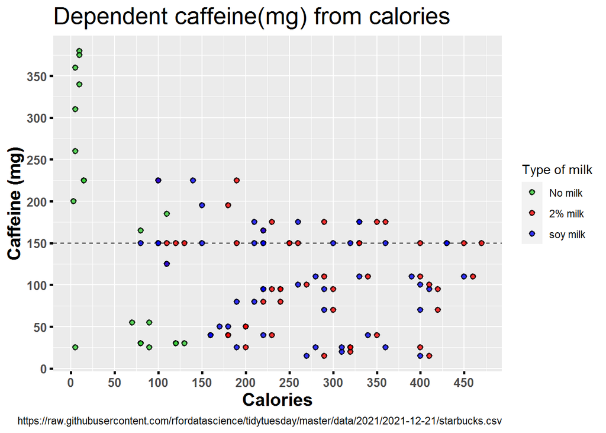

```r
m <- as.data.frame(table(fil_drinks$caffeine_mg)) #Создаем датасет с частотой значений
moda <- as.numeric(as.character(arrange(m,desc(Freq))[1,'Var1'])) #Самое популярное значение заносим в переменную moda.

fd <- ggplot(data=fil_drinks,
             mapping=aes(x = calories,
                         y = caffeine_mg)) +
  #Построим пунктирную линию моды значений кофе
    geom_hline(yintercept = moda, linetype = "dashed") +
    geom_point(aes(fill = factor(milk, levels = c(0,2,3))), #Зададим порядок значений
               shape=21,
               alpha=0.8,
               stroke=1) +
  #Сопоставим цвета и обозначения на графике
    scale_fill_manual(values = c("#33CC33", "#FF0000","#0000FF"),
                      labels = c("No milk","2% milk","soy milk")) +
  #Введем обозначения
    labs(title="Dependent caffeine(mg) from calories",
         caption = " https://raw.githubusercontent.com/rfordatascience/tidytuesday/master/data/2021/2021-12-21/starbucks.csv",
         x = "Calories",
         y = "Caffeine (mg)") +
    labs(fill = "Type of milk") +
  #Масштабируем оси графика
    scale_x_continuous(breaks = seq(from=0,to=500,by=50)) +
    scale_y_continuous(breaks = seq(from=0,to=400,by=50)) +
  #Зададим собственную тему
    theme(plot.title = element_text(size = 20),
          axis.text = element_text(size = 10,
                                   face = "bold"),
          axis.title = element_text(size = 15,
                                    face = "bold"),
          axis.ticks = element_line(color = "black",
                                    linewidth = 1),
          legend.position = "right")
fd
```

```r
#Сохраним график
ggsave(
  "figures/drinks.png", fd,
  dpi = 300, width = 20, height = 10, units = "cm")
```

# Задание №4

> Использйуте датасет про напитки из Старбакса из задания 2.

> На одном графике постройте гиcтограмму и плотность распределения содержания сахара во всех напитках. **geom_histogram и geom_density** преобразовывают ваши данные и отрисовывают либо каунты, либо плотность. Найдите способ, чтобы оба **geom_** отрисовывали значения по оси Y согласованно.

> Подпишите оси, добавьте название графика. Подберите цветовую палитру.

> Сохраните график в подходящем размере и удобном вам формате.

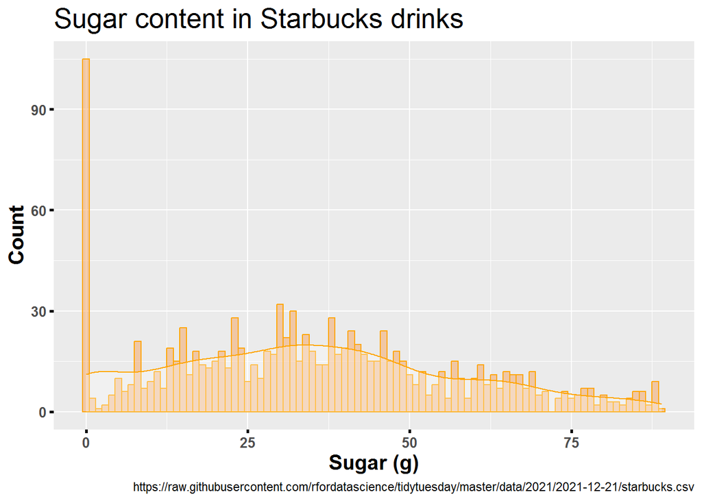

```r
hd <- ggplot(drinks, aes(x = sugar_g)) +
  #Консолидируем гистрамму с плотностью по количеству наблюдений
    geom_histogram(binwidth = 1,color="orange", fill = "sandybrown", alpha=0.5)+
    geom_density(aes(y = ..count..),color="orange",fill = "white", alpha = 0.3)+
  #Зададим обозначения
    labs(title="Sugar content in Starbucks drinks",
         caption = " https://raw.githubusercontent.com/rfordatascience/tidytuesday/master/data/2021/2021-12-21/starbucks.csv",
         x = "Sugar (g)",
         y = "Count") +
  #Масштабируем оси графика
    scale_x_continuous(breaks = seq(from=0,to=100,by=25)) +
    scale_y_continuous(breaks = seq(from=0,to=100,by=30)) +
  #Зададим собственную тему
    theme(plot.title = element_text(size = 20),
          axis.text = element_text(size = 10,
                                   face = "bold"),
          axis.title = element_text(size = 15,
                                    face = "bold"),
          axis.ticks = element_line(color = "black",
                                    linewidth = 1),
          legend.position = "right")
hd
```

```r
#Сохраним график
ggsave(
  "figures/histdrinks.png", hd,
  dpi = 300, width = 20, height = 10, units = "cm")
```

# Задание №5

> Загрузите датасет, содержащий информацию про **цветение сакуры в Японии за 1953-2019 года**. https://raw.githubusercontent.com/tacookson/data/master/sakura-flowering/sakura-modern.csv.

> Изучите датасет! Про него можно прочитать дополнительно, например, здесь: https://github.com/tacookson/data/blob/master/sakura-flowering/README.md.

> Информация про датасет:
- station_id - ID метеостанции (города),
- station_name - название города, где эта метеостанция расположена,
- latitude, longitude - широта и долгота метеостанции,
- year - год,
- flower_date - дата начала цветения сакуры,
- flower_doy - день с начала года, когда началось цветение сакуры,
- full_bloom_date - дата полного цвета сакуры,
- full_bloom_doy - день с начала года, на который пришелся полный цвет сакуры.

> Визуализируйте, как шел фронт цветения сакуры в Японии в разные годы, с помощью линейного графика - используйте **geom_line**. По горизонтали отложите года, по вертикали - дату или день начала цветения/полного цвета. Каждая кривая - это один город. Не забудьте сообщить, что вы решили визуализировать (какие переменные), в названиях осей и в названии графика.

> Сохраните график в подходящем размере и удобном вам формате.

```r
#Прочитаем данные
sak <- read_csv("https://raw.githubusercontent.com/tacookson/data/master/sakura-flowering/sakura-modern.csv") #Прочитаем датасет
#Удалим значения с NA
sak <- na.omit(sak)
#Покажем значения
head(sak)
```

```
## # A tibble: 6 x 9
##   station_id station_name latitude longitude  year flower_date flower_doy
##        <dbl> <chr>           <dbl>     <dbl> <dbl> <date>           <dbl>
## 1      47401 Wakkanai         45.4      142.  1953 1953-05-21         141
## 2      47401 Wakkanai         45.4      142.  1954 1954-05-17         137
## 3      47401 Wakkanai         45.4      142.  1955 1955-05-17         137
## 4      47401 Wakkanai         45.4      142.  1956 1956-05-12         133
## 5      47401 Wakkanai         45.4      142.  1957 1957-05-18         138
## 6      47401 Wakkanai         45.4      142.  1958 1958-05-23         143
## # i 2 more variables: full_bloom_date <date>, full_bloom_doy <dbl>
```

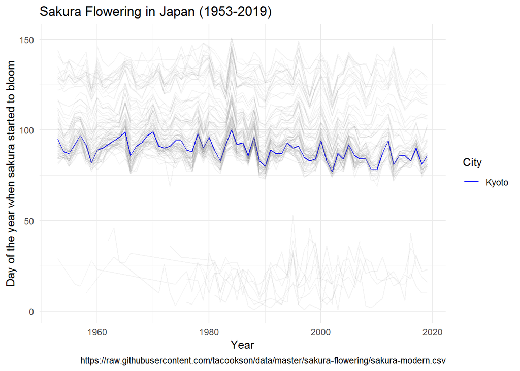

```r
#Выделим город Киото
sak$highlight <- ifelse(sak$station_name == 'Kyoto', 'Kyoto', 'Others')

s <- ggplot(data=sak, mapping=aes(x = year, y = flower_doy, group=station_name, color=highlight))+
    geom_line(aes(alpha=ifelse(highlight == "Kyoto", 1, 0.5))) + #Выделим по прозрачности города
    scale_color_manual(values=c("Kyoto"="blue", "Other"="grey90")) + #Выделим по цвету
    guides(alpha = "none") + #Уберем легенду с ifelse
  # Добавим обозначения
    labs(title="Sakura Flowering in Japan (1953-2019)",
         caption = "https://raw.githubusercontent.com/tacookson/data/master/sakura-flowering/sakura-modern.csv",
         x = "Year",
         y = "Day of the year when sakura started to bloom",
         color="City") +
    theme_minimal()

s
```

```r
#Сохраним график
ggsave(
  "figures/sakura.png", s,
  dpi = 300, width = 20, height = 10, units = "cm")
```